# 2 · A basic single-pulsar noise model in Discovery

In notebook 1 we made feather files. Now we **fit a noise model** to one pulsar.

A pulsar timing dataset is modelled as a sum of pieces:

$$ \mathbf{r} = \underbrace{M\,\boldsymbol{\epsilon}}_{\text{timing model}} \;+\; \underbrace{n_\mathrm{white}}_{\text{EFAC, EQUAD}} \;+\; \underbrace{n_\mathrm{red}}_{\text{spin noise (achromatic)}} \;+\; \underbrace{n_\mathrm{DM}}_{\text{dispersion measure (}\propto \nu^{-2}\text{)}} \;+\; \dots $$

In this **basic** model we include:

- **timing model** — marginalised analytically (a GP over the design matrix $M$),
- **white noise** — per-backend `EFAC` (scales the TOA errors) and `EQUAD` (added in quadrature),
- **red noise** — an achromatic power-law Gaussian process (spin noise),
- **DM noise** — a chromatic ($\nu^{-2}$) power-law Gaussian process.

Each power-law GP has two parameters: amplitude `log10_A` and spectral index `gamma`.

We sample the posterior with the **NUTS** Hamiltonian sampler, **save the chain**, pull out the **maximum-likelihood** parameters, and make a **corner plot**.

We build the model with `discovery`'s `signals` tools and sample with NUTS via `numpyro`. We read the chain back with `sampler.to_df()`, compute the likelihood ourselves, and assemble the corner plot with the `corner` package

```python
import os
import numpy as np
import pandas as pd
import matplotlib.pyplot as plt

import jax, jax.random
import discovery as ds
import discovery.signals as signals
import discovery.likelihood as likelihood
import discovery.prior as prior
import discovery.samplers.numpyro as ds_numpyro

DATADIR = "./my_feathers/"
psrname = "J0613-0200"

psr = ds.Pulsar.read_feather(os.path.join(DATADIR, psrname + ".feather"))
print("Loaded", psr.name, "with", len(psr.toas), "TOAs")
```

```
Loaded J0613-0200 with 3067 TOAs
```

### How big should the Gaussian processes be?

A power-law GP is represented by a set of Fourier frequencies (sine/cosine pairs). We choose how many from the data span and a maximum cadence: a longer cadence means coarser time resolution and therefore **fewer** components — faster to sample.

```python
max_cadence_days = 60
Tspan = signals.getspan(psr)
components = int(Tspan / (max_cadence_days * 86400.0))
print(f"Tspan = {Tspan/86400/365.25:.1f} yr -> {components} Fourier frequency components")
```

```
Tspan = 4.3 yr -> 26 Fourier frequency components
```

### Build the model

A Discovery model is just a **list of components** wrapped in a `PulsarLikelihood`. The first element is the data (residuals); the rest are the signals.

```python
model_components = []
model_components.append(psr.residuals)                                     # data
model_components.append(signals.makegp_timing(psr, svd=True))              # timing model (marginalised)
model_components.append(signals.makenoise_measurement(psr, tnequad=True))  # EFAC + EQUAD per backend

# Achromatic red (spin) noise, power-law Fourier GP
model_components.append(
    signals.makegp_fourier(psr, signals.powerlaw, components=components, name="red_noise"))

# DM noise: chromatic (freq^-2) power-law Fourier GP (freq^-2 basis)
model_components.append(
    signals.makegp_fourier(psr, signals.powerlaw, components=components,
                           fourierbasis=signals.dmfourierbasis, name="dm_gp"))

model = likelihood.PulsarLikelihood(model_components)

print("Free parameters in the model:")
for p in model.logL.params:
    print("   ", p)
```

```
Free parameters in the model:
    J0613-0200_KAT_MKBF_efac
    J0613-0200_KAT_MKBF_log10_tnequad
    J0613-0200_dm_gp_gamma
    J0613-0200_dm_gp_log10_A
    J0613-0200_red_noise_gamma
    J0613-0200_red_noise_log10_A
```

### Set the priors

Every free parameter gets a flat (uniform) prior. We set the ranges explicitly so you can see exactly what is assumed.

```python
prior.priordict_standard.update({
    r"(.*_)?efac":              [0.5, 2.0],
    r"(.*_)?log10_tnequad":     [-10, -5],
    r"(.*_)?red_noise_log10_A.*": [-18, -11],
    r"(.*_)?red_noise_gamma.*":   [0, 7],
    r"(.*_)?dm_gp_log10_A":     [-18, -11],
    r"(.*_)?dm_gp_gamma":       [0, 7],
})
for p in model.logL.params:
    print(f"   {p:40s} {prior.getprior_uniform(p, {})}")
```

[output not shown]

### Sample the posterior with NUTS

`makemodel_transformed` reparametrizes the parameters to an unconstrained space for efficient Hamiltonian sampling; NUTS then explores it. `num_warmup` tunes the sampler; `num_samples` are the kept draws. A real analysis would use more — these keep the workshop fast.

```python
npmodel = ds_numpyro.makemodel_transformed(model.logL)
sampler = ds_numpyro.makesampler_nuts(npmodel, num_warmup=200, num_samples=500)

key = jax.random.PRNGKey(123456789)     # fixed seed -> reproducible chain
sampler.run(key)                 # the part that takes a minute or two
```

### Save the chain

```python
chain = sampler.to_df()
chain = chain[[p for p in model.logL.params]].copy()      # keep just the model parameters
# evaluate the (marginalised) log-likelihood at every posterior sample
chain["logl"] = np.asarray(jax.lax.map(model.logL, {p: chain[p].values for p in model.logL.params}))

outdir = "./results"
os.makedirs(outdir, exist_ok=True)
save_base = os.path.join(outdir, psrname + "_basic")
chain.to_pickle(save_base + ".pickle")
print("saved", save_base + ".pickle", " shape:", chain.shape)
chain.head()
```

[output not shown]

|  | J0613-0200_KAT_MKBF_efac | J0613-0200_KAT_MKBF_log10_tnequad | J0613-0200_dm_gp_gamma | J0613-0200_dm_gp_log10_A | J0613-0200_red_noise_gamma | J0613-0200_red_noise_log10_A | logl |
| --- | --- | --- | --- | --- | --- | --- | --- |
| 0 | 0.996750 | -6.657143 | 3.463371 | -13.226989 | 3.236180 | -14.142585 | 38705.549666 |
| 1 | 1.038061 | -6.659991 | 2.840451 | -13.355897 | 3.857163 | -14.594700 | 38705.013871 |
| 2 | 1.009867 | -6.673874 | 2.297405 | -13.425100 | 4.332372 | -14.570855 | 38706.096153 |
| 3 | 0.987853 | -6.635551 | 2.137052 | -13.359099 | 5.886864 | -16.909103 | 38704.671660 |
| 4 | 0.987089 | -6.497728 | 3.676526 | -13.380128 | 1.374153 | -17.483554 | 38704.391774 |

### Maximum-likelihood parameters

The "best fit" point estimate is the sample with the highest log-likelihood. We also save it to JSON — later analyses (e.g. a common-noise / GWB search) read these per-pulsar values as a fixed noise dictionary.

```python
import json

ml_idx = chain["logl"].idxmax()
ml_params = chain.loc[ml_idx].to_dict()

with open(save_base + ".json", "w") as f:
    json.dump(ml_params, f, indent=2)

print("Maximum-likelihood parameters:")
for k, v in ml_params.items():
    if k == "logl":
        continue
    print(f"   {k:40s} = {v:+.3f}")
```

```
Maximum-likelihood parameters:
   J0613-0200_KAT_MKBF_efac                 = +1.006
   J0613-0200_KAT_MKBF_log10_tnequad        = -6.597
   J0613-0200_dm_gp_gamma                   = +2.876
   J0613-0200_dm_gp_log10_A                 = -13.365
   J0613-0200_red_noise_gamma               = +5.849
   J0613-0200_red_noise_log10_A             = -17.741
```

### Corner plot

A corner plot shows the 1-D marginal posterior of each parameter (the histograms on the diagonal) and every 2-D joint posterior (the off-diagonal contours). It is the standard way to read off measured values and spot correlations. We build it by hand with the `corner` package.

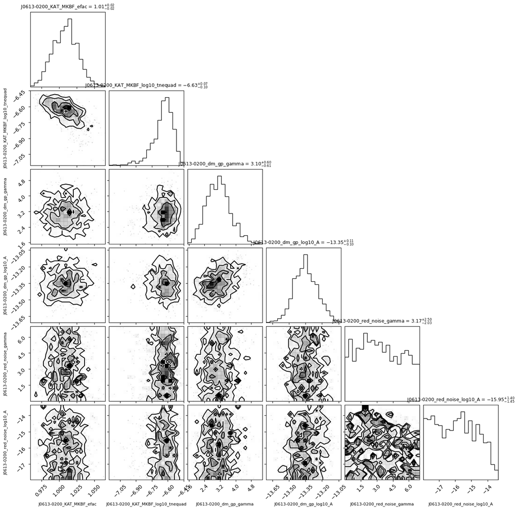

```python
import corner

labels = [c for c in chain.columns if c != "logl"]
fig = corner.corner(
    chain[labels].values,
    labels=labels,
    show_titles=True,
    title_fmt=".2f",
    title_kwargs={"fontsize": 9},
    label_kwargs={"fontsize": 8},
)
fig.savefig(save_base + "_corner.png", dpi=120, bbox_inches="tight")
plt.show()
```

**How to read it**

- `red_noise_log10_A`, `red_noise_gamma` — amplitude and slope of the **spin noise**.
- `dm_gp_log10_A`, `dm_gp_gamma` — amplitude and slope of the **DM noise**.
- The `efac`/`log10_tnequad` columns are the per-backend **white-noise** parameters.

If a `log10_A` posterior is a clean peak well above the lower prior edge, that process is **detected**. If instead it piles up against the lower edge of the prior (an upper limit, no peak), the data don't require that process — it is **not significant**. We explore exactly that in the next notebook.

➡️ **Next:** `03_custom_noise_model.ipynb` — choose your own pulsar and noise terms.